# teengamb homework

Kimberly Rodriguez

Stat 364

```r
library(faraway)
```

```r
summary(teengamb)
```

```
      sex             status          income           verbal
 Min.   :0.0000   Min.   :18.00   Min.   : 0.600   Min.   : 1.00
 1st Qu.:0.0000   1st Qu.:28.00   1st Qu.: 2.000   1st Qu.: 6.00
 Median :0.0000   Median :43.00   Median : 3.250   Median : 7.00
 Mean   :0.4043   Mean   :45.23   Mean   : 4.642   Mean   : 6.66
 3rd Qu.:1.0000   3rd Qu.:61.50   3rd Qu.: 6.210   3rd Qu.: 8.00
 Max.   :1.0000   Max.   :75.00   Max.   :15.000   Max.   :10.00
     gamble
 Min.   :  0.0
 1st Qu.:  1.1
 Median :  6.0
 Mean   : 19.3
 3rd Qu.: 19.4
 Max.   :156.0
```

```r
attach(teengamb)
```

(a) Check the constant variance assumption for the errors.

```r
m1 <- lm(gamble~., data=teengamb)
```

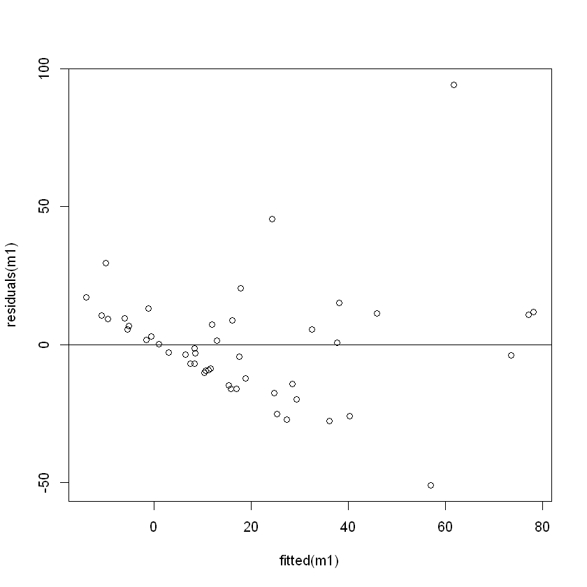

```r
plot(fitted(m1),residuals(m1))
abline(h=0)
```

**There is heteroskedasticity (non-constant variance). The residuals show a pattern where they spread out more as the fitted values increase.**

(b) Check the normality assumption.

```r
shapiro.test(residuals(m1))
```

```
	Shapiro-Wilk normality test

data:  residuals(m1)
W = 0.86839, p-value = 8.16e-05
```

**we reject the null hypothesis since the p-value (8.16e-05) is really small so, the residuals do not follow a normal distribution**

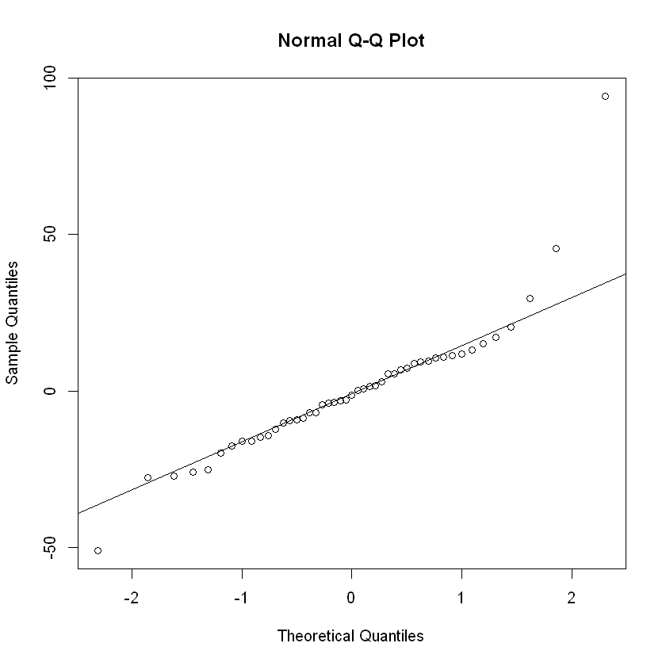

```r
qqnorm(m1$residuals)
qqline(m1$residuals)
```

**The points are fairly centered around the line in the middle but, as you look at the ends you can see that they are moving away from the line which suggest skewdness (fat tails). Both the plot and the shapiro test suggest that the residuals don't quite follow a normal distribution.**

(c) Check for large leverage points.

```r
h<- hatvalues(m1)
```

```r
h
```

**1**

0.079882259622872

**2**

0.108512913713554

**3**

0.0634764277567192

**4**

0.102739547751889

**5**

0.138669458196884

**6**

0.163785627771839

**7**

0.0689331584642024

**8**

0.0711042169896244

**9**

0.0705161861165045

**10**

0.108710173867337

**11**

0.100960447471684

**12**

0.0700498169580507

**13**

0.105292940854054

**14**

0.0736377113445047

**15**

0.0582614583639498

**16**

0.0837211811658072

**17**

0.140003421518898

**18**

0.119947533102703

**19**

0.0690587207641707

**20**

0.0877668668821125

**21**

0.0501069142293234

**22**

0.114966644319516

**23**

0.066932340718087

**24**

0.123804627236485

**25**

0.102732291541942

**26**

0.112294283377646

**27**

0.105834040613965

**28**

0.110106330244634

**29**

0.0772989784715586

**30**

0.0514594639663611

**31**

0.239503144928445

**32**

0.106775832863231

**33**

0.22134388524579

**34**

0.10707672396993

**35**

0.311802935356313

**36**

0.0465907100550868

**37**

0.082124329816724

**38**

0.0976136083384265

**39**

0.0915520821690126

**40**

0.0873978643981781

**41**

0.116480076055001

**42**

0.301608765399792

**43**

0.0871576508259599

**44**

0.0689742785118415

**45**

0.067374615792675

**46**

0.0871833341385946

**47**

0.0788741787381196

```r
lev<-h/(1-h)
```

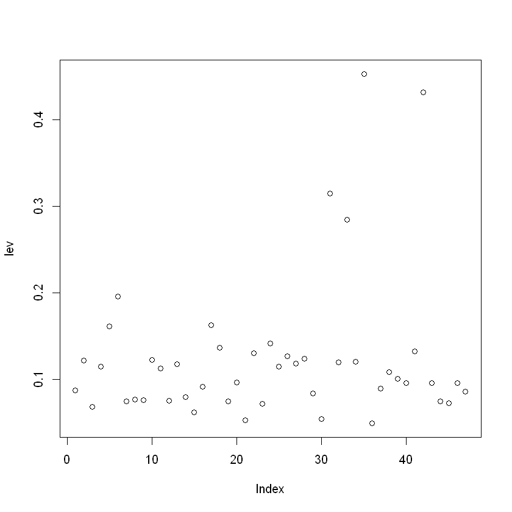

```r
plot(lev)
```

```r
lev
```

**1**

0.0868174322887533

**2**

0.121721240142213

**3**

0.0677787827642954

**4**

0.114503595354585

**5**

0.160994474788496

**6**

0.195865597640255

**7**

0.0740367451497864

**8**

0.0765470338978062

**9**

0.0758659645958538

**10**

0.121969499347967

**11**

0.112298115458612

**12**

0.0753264188076307

**13**

0.11768426299728

**14**

0.0794912662640673

**15**

0.0618658531939599

**16**

0.0913708572597236

**17**

0.162795323867646

**18**

0.136295888727622

**19**

0.0741816076958776

**20**

0.0962110053842678

**21**

0.0527500568010453

**22**

0.129900916820385

**23**

0.071733641234118

**24**

0.141297969705097

**25**

0.114494582356571

**26**

0.12649944826864

**27**

0.118360623666142

**28**

0.123729760067743

**29**

0.0837746752935354

**30**

0.0542512017267506

**31**

0.314929829533497

**32**

0.119539793919259

**33**

0.284263978734257

**34**

0.119917048692013

**35**

0.453072166934842

**36**

0.0488674806785014

**37**

0.0894721719776338

**38**

0.108172739793526

**39**

0.100778570099651

**40**

0.0957677623015236

**41**

0.131836388629366

**42**

0.431862186203477

**43**

0.0954794120855831

**44**

0.0740841814784585

**45**

0.0722418850414835

**46**

0.0955102348578633

**47**

0.0856280183635144

```r
which.max(lev)
```

**35:** 35

```r
max(lev[lev!=max(lev)])
```

0.431862186203477

**The highest leverage values are the 35th and 42nd values.**

(d) Check for outliers.

```r
summary(m1)
```

```
Call:
lm(formula = gamble ~ ., data = teengamb)

Residuals:
    Min      1Q  Median      3Q     Max
-51.082 -11.320  -1.451   9.452  94.252

Coefficients:
             Estimate Std. Error t value Pr(>|t|)
(Intercept)  22.55565   17.19680   1.312   0.1968
sex         -22.11833    8.21111  -2.694   0.0101 *
status        0.05223    0.28111   0.186   0.8535
income        4.96198    1.02539   4.839 1.79e-05 ***
verbal       -2.95949    2.17215  -1.362   0.1803
---
Signif. codes:  0 '***' 0.001 '**' 0.01 '*' 0.05 '.' 0.1 ' ' 1

Residual standard error: 22.69 on 42 degrees of freedom
Multiple R-squared:  0.5267,	Adjusted R-squared:  0.4816
F-statistic: 11.69 on 4 and 42 DF,  p-value: 1.815e-06
```

```r
nrow(teengamb)
```

47

```r
g<- rstudent(m1)
```

```r
g[which.max(abs(g))]
```

**24:** 6.01611634452456

```r
qt(.05/94,44)
```

-3.50470844092336

**24 is an outlier since it's larger than 3.5047**

(e) Check for influential points.

```r
cd<-cooks.distance(m1)
```

```r
cd
```

**1**

0.00415787352577159

**2**

0.00465782679835409

**3**

0.000839054409832694

**4**

0.015174472127946

**5**

0.0632712105557904

**6**

0.000810564311126434

**7**

0.00152412438899394

**8**

0.00484784034893934

**9**

0.00148760249128618

**10**

0.00567582404754759

**11**

0.000123208951567338

**12**

0.000301568431460514

**13**

7.02849041822397e-07

**14**

0.0030294090041333

**15**

0.000207108356071782

**16**

0.0114743664496716

**17**

0.0469303124058022

**18**

0.0464950977763482

**19**

0.00534835578224927

**20**

0.0104242800912337

**21**

0.00552536210179915

**22**

0.00523293006616999

**23**

0.0222108446687478

**24**

0.556501130536252

**25**

2.42427935844816e-05

**26**

0.00465186222369275

**27**

0.0344262744807321

**28**

0.00413103359858745

**29**

0.00166961238608416

**30**

0.00871826974975612

**31**

0.019040236022613

**32**

0.0117908770086255

**33**

0.0195668552378462

**34**

0.000673590741482453

**35**

0.0530430423756518

**36**

0.0414110107080565

**37**

0.0159867280432639

**38**

0.00588616132936135

**39**

0.112449831799926

**40**

0.0032050418161246

**41**

0.000122105822510644

**42**

0.00353498988239077

**43**

0.000780620974184004

**44**

0.0068570738761637

**45**

0.000893972021021452

**46**

8.07196663572924e-05

**47**

0.0018545030664076

```r
which.max(cd)
```

**24:** 24

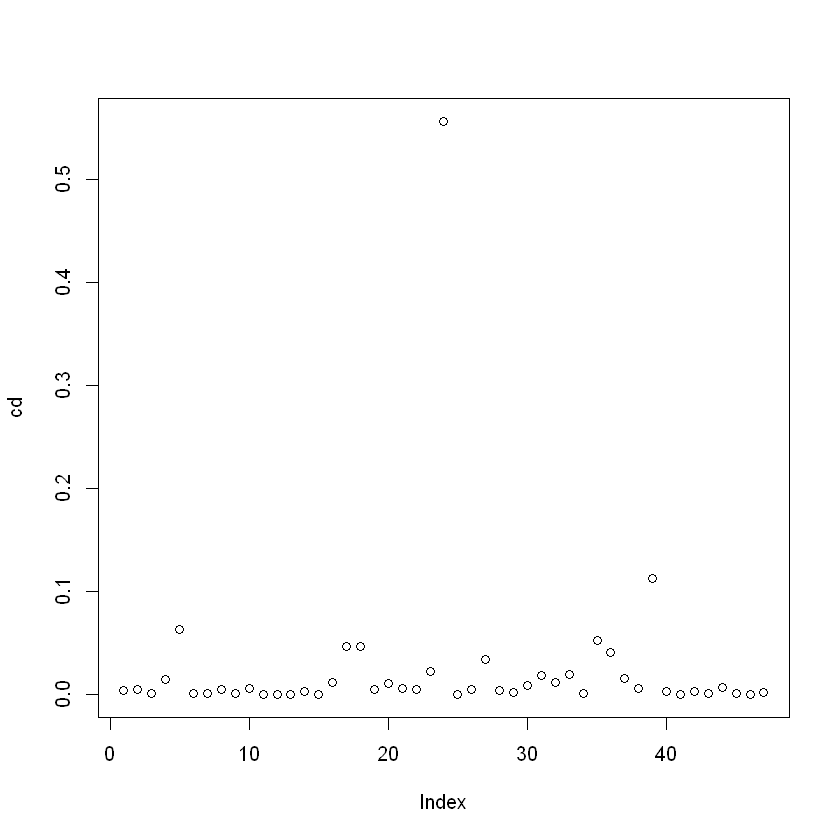

```r
plot(cd)
```

(f) Check the structure of the relationship between the predictors and the response.

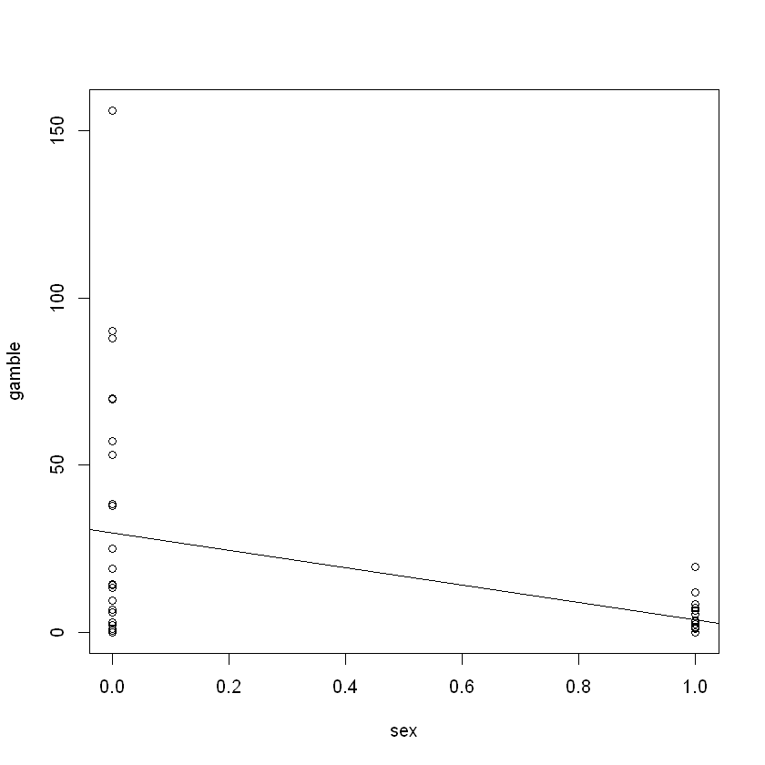

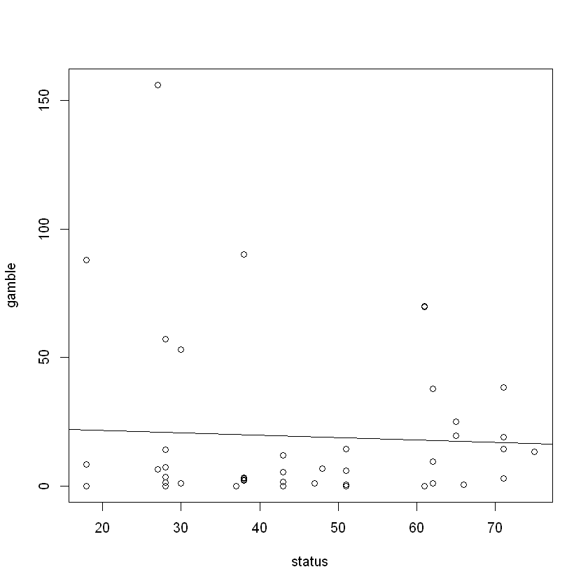

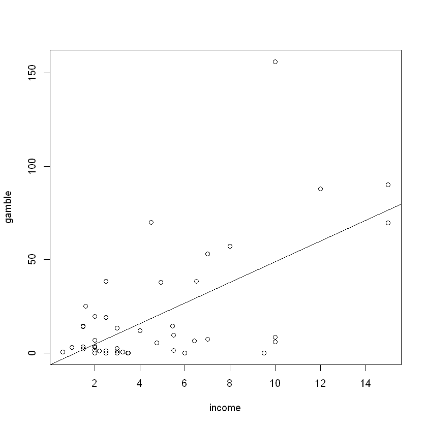

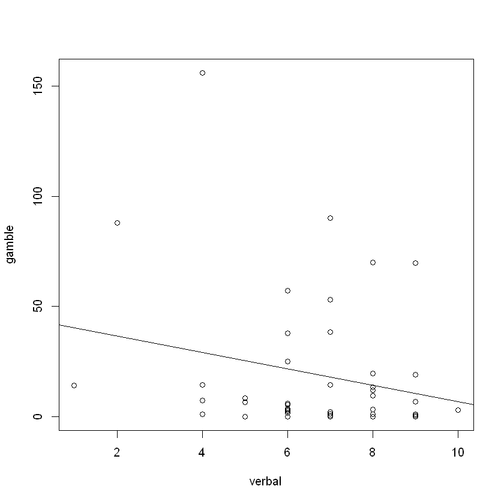

```r
plot(sex, gamble)
abline(lm(gamble ~ sex))
plot(status, gamble)
abline(lm(gamble ~ status))
plot(income, gamble)
abline(lm(gamble ~ income))
plot(verbal, gamble)
abline(lm(gamble ~ verbal))
```